# B99 blog post

Catherine Carlo

2023-06-06

Hello! For this blog post I will be analyzing the questions of Jeopardy! Being a big fan of the show, I thought it might be fun to try to unlock the secrets of Jeopardy!’s questions. The data is from r/datasets on reddit (https://www.reddit.com/r/datasets/comments/1uyd0t/200000_jeopardy_questions_in_a_json_file/). It contains about 83% of all Jeopardy! questions ever and it sourced from j-archive.com, an archive of Jeopardy! questions.

There are a ton of ways to go with this data. I am chosing to focus on two research questions. 1: Is there any sentiment related to the questions? Are they positive? Is there one emotion more associated with the questions over another? 2: What topics are these questions covering? History? Sports?

There are numerous other ways I could have taken this project including analysis of the questions over time, how similar questions are to each other, lexical diversity, relationships between question value, round, question length, answer length, etc..

First thing’s first, let’s load in some packages.

```r
library(tidyverse)
library(tidytext)
library(rvest)
library(topicmodels)
```

Let’s start to explore some of the data.

```r
jeopardy <- read.csv("JEOPARDY_CSV.csv")
head(jeopardy)
```

```
##   Show.Number   Air.Date     Round                        Category Value
## 1        4680 2004-12-31 Jeopardy!                         HISTORY  $200
## 2        4680 2004-12-31 Jeopardy! ESPN's TOP 10 ALL-TIME ATHLETES  $200
## 3        4680 2004-12-31 Jeopardy!     EVERYBODY TALKS ABOUT IT...  $200
## 4        4680 2004-12-31 Jeopardy!                THE COMPANY LINE  $200
## 5        4680 2004-12-31 Jeopardy!             EPITAPHS & TRIBUTES  $200
## 6        4680 2004-12-31 Jeopardy!                  3-LETTER WORDS  $200
##                                                                                                      Question
## 1            For the last 8 years of his life, Galileo was under house arrest for espousing this man's theory
## 2 No. 2: 1912 Olympian; football star at Carlisle Indian School; 6 MLB seasons with the Reds, Giants & Braves
## 3                    The city of Yuma in this state has a record average of 4,055 hours of sunshine each year
## 4                        In 1963, live on "The Art Linkletter Show", this company served its billionth burger
## 5    Signer of the Dec. of Indep., framer of the Constitution of Mass., second President of the United States
## 6                               In the title of an Aesop fable, this insect shared billing with a grasshopper
##       Answer
## 1 Copernicus
## 2 Jim Thorpe
## 3    Arizona
## 4 McDonald's
## 5 John Adams
## 6    the ant
```

```r
range(jeopardy$Air.Date)
```

```
## [1] "1984-09-10" "2012-01-27"
```

```r
nrow(jeopardy)
```

```
## [1] 216930
```

For the two research questions selected prior, I’m only going to use the Show.Number, Round and Question columns.

```r
#jeopardy <- cbind(ID = 1:nrow(jeopardy), jeopardy)
# adding ID column for questions

jeoPARTY <- jeopardy %>%
  select('Show.Number','Round','Question')
head(jeoPARTY)
```

```
##   Show.Number     Round
## 1        4680 Jeopardy!
## 2        4680 Jeopardy!
## 3        4680 Jeopardy!
## 4        4680 Jeopardy!
## 5        4680 Jeopardy!
## 6        4680 Jeopardy!
##                                                                                                      Question
## 1            For the last 8 years of his life, Galileo was under house arrest for espousing this man's theory
## 2 No. 2: 1912 Olympian; football star at Carlisle Indian School; 6 MLB seasons with the Reds, Giants & Braves
## 3                    The city of Yuma in this state has a record average of 4,055 hours of sunshine each year
## 4                        In 1963, live on "The Art Linkletter Show", this company served its billionth burger
## 5    Signer of the Dec. of Indep., framer of the Constitution of Mass., second President of the United States
## 6                               In the title of an Aesop fable, this insect shared billing with a grasshopper
```

there are plenty of filler words used in making these questions (What, which, the, a, etc.). I chose to add in these below.

```r
new_stops <- tibble(word =c('http','https','www','www.j','archive.com',
                            '_blank','href','ha','na','target','media','jpg',
                            'called','city','clue','1','2','3','4','5','6',
                            '7','8','9','10','11','12','01','02','03','04',
                            '05','06','07','08','09','010','mp3',
                            '2004','2005','book','film','named',
                            'called','type','u.s','country','crew','word',
                            'title','2008','2007','2006','2009','2010',
                            '2011','american','term','french','island'))
stop_words <- stop_words %>%
  bind_rows(new_stops)
```

Making a tibble of all the questions in the dataset.

```r
jeo_tib <- jeoPARTY %>%
  tibble %>%
  unnest_tokens(output=word,
                input=Question) %>%
  anti_join(stop_words)
jeo_tib
```

```
## # A tibble: 1,494,838 × 3
##    Show.Number Round     word
##          <int> <chr>     <chr>
##  1        4680 Jeopardy! life
##  2        4680 Jeopardy! galileo
##  3        4680 Jeopardy! house
##  4        4680 Jeopardy! arrest
##  5        4680 Jeopardy! espousing
##  6        4680 Jeopardy! man's
##  7        4680 Jeopardy! theory
##  8        4680 Jeopardy! 1912
##  9        4680 Jeopardy! olympian
## 10        4680 Jeopardy! football
## # ℹ 1,494,828 more rows
```

great! now we have a tibble. What values are in it?

```r
unique(jeo_tib$word) %>%
  tibble() %>%
  nrow()
```

```
## [1] 98322
```

there are nearly 100k unique words after removing stop words! and about 1.5 Million total words used in the 216,000 questions.

hmm… which words are the most frequently used?

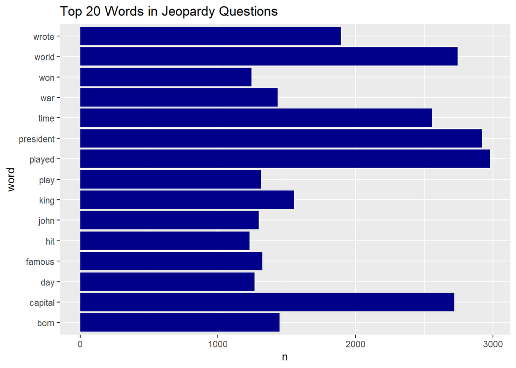

```r
counts <- jeo_tib %>%
  count(Round,word, sort=T)

counts %>%
  top_n(20) %>%
  ggplot() +
  geom_col(aes(x = n,
               y=word),
           fill='dark blue') +
  ggtitle("Top 20 Words in Jeopardy Questions")
```

Played, President, World, Capital and Time are the top 5 most used words, and all at over a count of 2000! This is starting to give some clues regarding what the questions might be about…

Let’s get into research question 1: question sentiments.

are the questions positive??

```r
jeo_sent <- jeo_tib %>%
  inner_join(get_sentiments(),
             relationship="many-to-many") %>%
  count(Round,sentiment) %>%
  pivot_wider(names_from=sentiment,
              values_from=n)
jeo_sent
```

```
## # A tibble: 4 × 3
##   Round            negative positive
##   <chr>               <int>    <int>
## 1 Double Jeopardy!    28759    29401
## 2 Final Jeopardy!       851     1166
## 3 Jeopardy!           27992    29033
## 4 Tiebreaker             NA        1
```

in this table it looks to be pretty even positive/negative across the rounds. let’s visualize

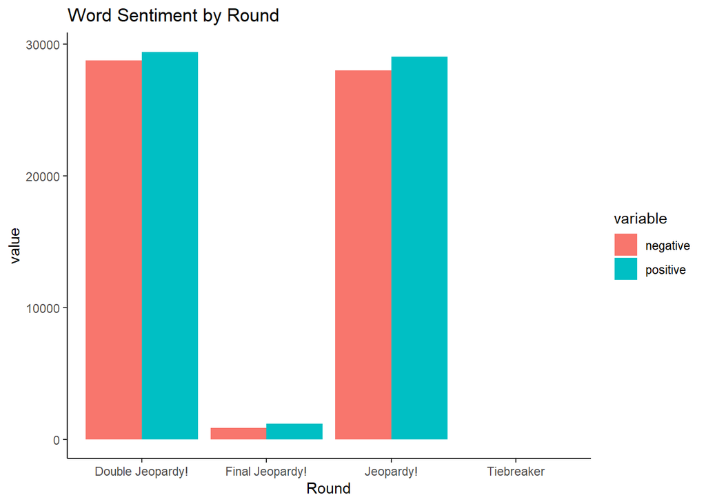

```r
jeo_sent.melt <-reshape2::melt(jeo_sent,id='Round')
p1 <- ggplot(data=jeo_sent.melt, aes(x=Round, y=value, fill=variable))
p1 <- p1 + geom_col(position='dodge')
p1 <- p1 + theme_classic()
p1 <- p1 + labs(title="Word Sentiment by Round")
p1
```

yep, pretty even! This makes sense. From watching the show, the questions are designed to be pretty neutral.

But, what about emotions? Let’s take a look.

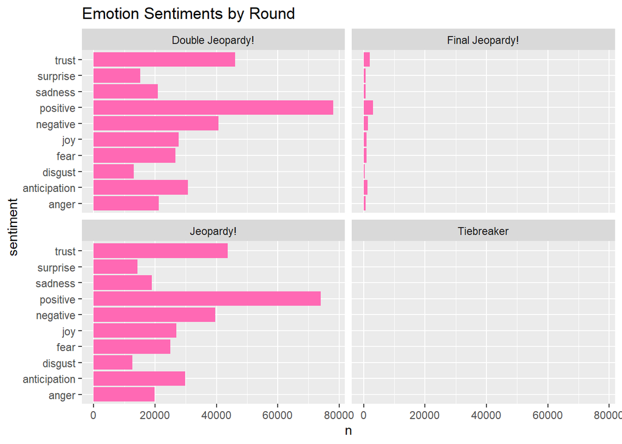

```r
jeo_sent_2 <-  jeo_tib %>%
  inner_join(get_sentiments("nrc")) %>%
  count(Round,sentiment) %>%
  ggplot() +
  geom_col(aes(x=n,
               y=sentiment),fill="hot pink") +
  facet_wrap(~Round) +
  ggtitle("Emotion Sentiments by Round")
jeo_sent_2
```

Here we can see the breakdown of different emotions. Jeorpardy! and Double Jeopardy! are insanely similarly distributed between the different emothions. The only real difference is that Double Jeopardy! has a touch of more sadness than Jeopardy!. It seems that Final Jeopardy! follows a similar trend as the other two standard rounds. Tiebreaker is really negligable since there have only been 4 total questions in the show’s history.

time for researh question number 2: what topics are being discussed in the questions.

step 1: making a DTM

```r
dtm_jeo <- counts %>%
  cast_dtm(document = Round,
           term = word ,
           value =n )
dtm_jeo
```

```
## <<DocumentTermMatrix (documents: 4, terms: 98322)>>
## Non-/sparse entries: 150185/243103
## Sparsity           : 62%
## Maximal term length: 31
## Weighting          : term frequency (tf)
```

step 2: making some LDAs. Decided to test out 3, 4 and 5.

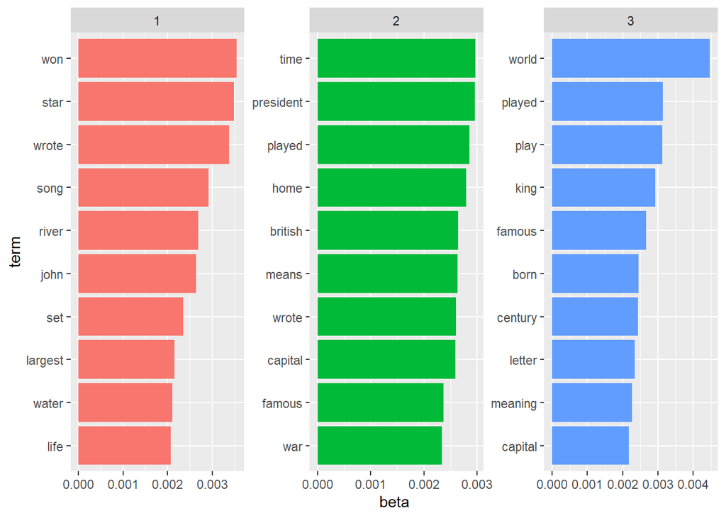

```r
lda_3 <- LDA(dtm_jeo, k = 3,
           control = list(seed = 123))
topics_3 <- tidy(lda_3,
                 matrix = "beta")
top_terms_3 <- topics_3 %>%
  group_by(topic) %>%
  slice_max(beta, n = 10) %>%
  ungroup() %>%
  arrange(topic, -beta)

top_terms_3_plot <- top_terms_3 %>%
  mutate(term = reorder_within(term, beta, topic)) %>%
  ggplot(aes(x = beta, y = term, fill = factor(topic))) +
  geom_col(show.legend = FALSE) +
  facet_wrap(~factor(topic), scales = "free" ) +
  scale_y_reordered()
top_terms_3_plot
```

```r
lda_4 <- LDA(dtm_jeo, k = 4,
           control = list(seed = 123))
lda_4
```

```
## A LDA_VEM topic model with 4 topics.
```

```r
topics_4 <- tidy(lda_4,
                 matrix = "beta")
top_terms_4 <- topics_4 %>%
  group_by(topic) %>%
  slice_max(beta, n = 10) %>%
  ungroup() %>%
  arrange(topic, -beta)
top_terms_4
```

```
## # A tibble: 40 × 3
##    topic term       beta
##    <int> <chr>     <dbl>
##  1     1 star    0.00402
##  2     1 won     0.00393
##  3     1 song    0.00346
##  4     1 set     0.00270
##  5     1 largest 0.00249
##  6     1 john    0.00232
##  7     1 river   0.00230
##  8     1 wrote   0.00230
##  9     1 classic 0.00220
## 10     1 family  0.00213
## # ℹ 30 more rows
```

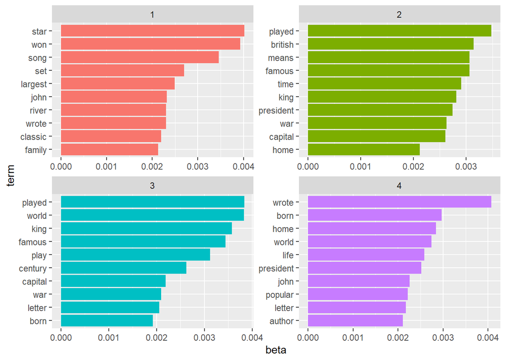

```r
top_terms_4_plot <- top_terms_4 %>%
  mutate(term = reorder_within(term, beta, topic)) %>%
  ggplot(aes(x = beta, y = term, fill = factor(topic))) +
  geom_col(show.legend = FALSE) +
  facet_wrap(~factor(topic), scales = "free" ) +
  scale_y_reordered()
top_terms_4_plot
```

topic 1: music/entertainment topic 2: literature/politicians topic 3: theater (shakespeare?) topic 4: history

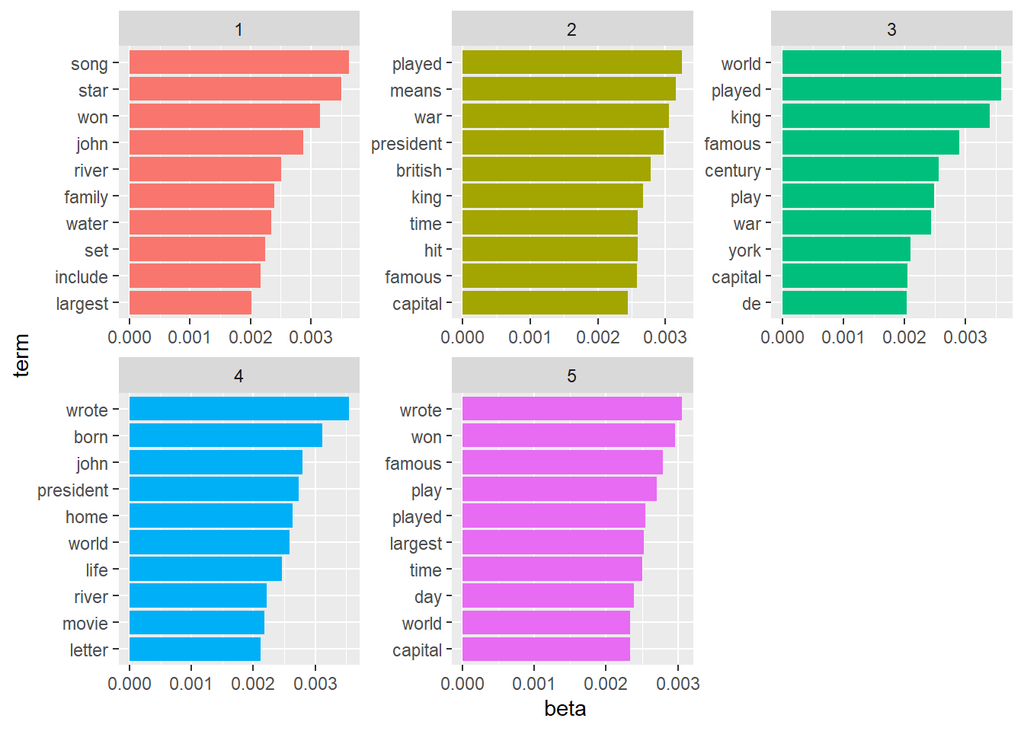

```r
lda_5 <- LDA(dtm_jeo, k = 5,
           control = list(seed = 123))
topics_5 <- tidy(lda_5,
                 matrix = "beta")
top_terms_5 <- topics_5 %>%
  group_by(topic) %>%
  slice_max(beta, n = 10) %>%
  ungroup() %>%
  arrange(topic, -beta)

top_terms_5_plot <- top_terms_5 %>%
  mutate(term = reorder_within(term, beta, topic)) %>%
  ggplot(aes(x = beta, y = term, fill = factor(topic))) +
  geom_col(show.legend = FALSE) +
  facet_wrap(~factor(topic), scales = "free" ) +
  scale_y_reordered()
top_terms_5_plot
```

gonna stick with 4 topics, seems to have the least overlap between topics & the most encompassing across different topics. That’s why I only labeled the topics for lda_4. Let’s take a look at the gamma for 4 topics to see how often the topics are referred to throughout the Rounds.

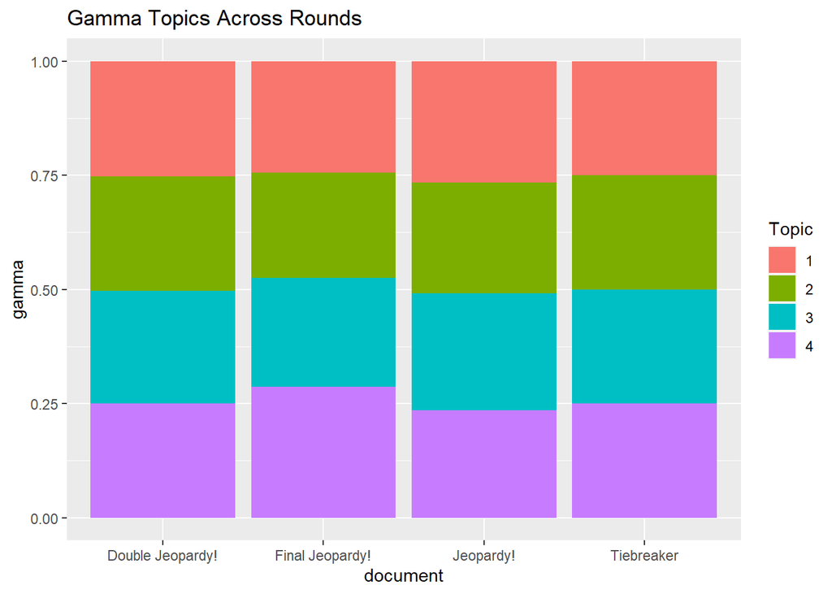

```r
jeo_documents <- tidy(lda_4,matrix = "gamma")
jeo_documents %>%
  #filter(document %in% c(1,2,3,4,5,6)) %>%
  ggplot() +
  geom_col(aes(x=document,
               y=gamma,
               fill=factor(topic))) +
    ggtitle("Gamma Topics Across Rounds")+
  scale_fill_discrete(name = "Topic")
```

So, what are our takeaways? The questions are neutral in tone and emotion. Questions are also broken evenly into 4 topics/categories (music, theater, literature and history). This was a little surprising to me. There are questions about sports and inventions and geography in the show. I think the music topic (#1) relates more to modern entertainment (sports, celebrities, music artists). This also just shows how much of jeopardy is more about the liberal arts topics, if you will.

Challenge wise, There was so much data to work with and so many different directions to go in. If given more time I think it would’ve been interesting to explore the relationship between question and answer with topic. Also would be interesting to see how the questions have changed since the show’s beginning, if atall.